# 🎓 Master of Science in Applied Data Science 🎓

## 🤖 Machine Learning and Predictive Analytics 🤖

## 📅 Week 2: Descend into Data with Linear Algebra 📅

## Instructions

- **Purpose:** This assignment dives deeper into data transformation and feature engineering. It also introduces regularization, equipping you to combat overfitting.
- **Prerequisites:**
  - Understanding of concepts from Week 1: "What Do Machines Learn?"
  - Python proficiency with `NumPy`, `Pandas`, `Matplotlib`, and `Scikit-learn`.
- **Completing the Assignment:**
  - Address all questions thoroughly.
  - Include explanations with your code to justify your choices.
  - Pay close attention to the assigned point values in each part.

**Tips**

- **Collaborate:** Discuss, but submit your own work 🤝
- **Experiment:** Tinkering with code and parameters is how you learn! 🧪
- **Ask for Help:** Reach out to your instructor/TA for guidance if stuck. 💡

## Question 1: Feature Engineering & Wrangling (35 points)

### **Part A: Data Loading and Cleaning (10 Points)**

```python
import numpy as np
import pandas as pd
import matplotlib.pyplot as plt
```

2. **Load Your Dataset:** Load the dataset labeled `Week_2_Train.csv` into a Pandas DataFrame. Replace the placeholders with the correct file path and format based on how the data is stored (CSV, Excel, etc.) 💾

```python
# Load Dataset: Expand the dataset from Week 1, located in `Week_2_Dataset.csv`. Include the new categorical features. Address any missing values or inconsistencies you find.
df = pd.read_csv('/Users/edwinhsu/Assignment/Machine Learning & Predictive Analytics/Week_2_Train-1.csv')
df
```

|  | age | workclass | fnlwgt | education | education-num | marital-status | occupation | relationship | race | sex | capital-gain | capital-loss | hours-per-week | native-country | class |
| --- | --- | --- | --- | --- | --- | --- | --- | --- | --- | --- | --- | --- | --- | --- | --- |
| 0 | 18 | Private | 300379.0 | 12th | 8 | Never-married | Adm-clerical | Own-child | White | Male | 0.0 | 0.0 | 12 | United-States | <=50K |
| 1 | 29 | Private | 34292.0 | HS-grad | 9 | Never-married | Other-service | Own-child | White | Male | 0.0 | 0.0 | 38 | United-States | <=50K |
| 2 | 29 | Private | 102345.0 | Some-college | 10 | Never-married | Tech-support | Not-in-family | White | Male | 0.0 | 0.0 | 52 | United-States | <=50K |
| 3 | 49 | Self-emp-inc | 83444.0 | Bachelors | 13 | Married-civ-spouse | Sales | Husband | White | Male | 0.0 | 0.0 | 85 | United-States | >50K |
| 4 | 38 | Private | 40077.0 | HS-grad | 9 | Married-civ-spouse | Craft-repair | Husband | White | Male | 0.0 | 0.0 | 50 | United-States | >50K |
| ... | ... | ... | ... | ... | ... | ... | ... | ... | ... | ... | ... | ... | ... | ... | ... |
| 39068 | 42 | Federal-gov | 37997.0 | Bachelors | 13 | Married-civ-spouse | Exec-managerial | Husband | White | Male | 0.0 | 0.0 | 40 | United-States | <=50K |
| 39069 | 65 | Self-emp-not-inc | 326936.0 | HS-grad | 9 | Married-civ-spouse | Sales | Wife | White | Female | 0.0 | 0.0 | 40 | United-States | <=50K |
| 39070 | 44 | Self-emp-inc | 229466.0 | Some-college | 10 | Married-civ-spouse | Exec-managerial | Husband | White | Male | 0.0 | 0.0 | 50 | United-States | >50K |
| 39071 | 35 | Private | 265954.0 | Bachelors | 13 | Never-married | Handlers-cleaners | Not-in-family | Black | Male | 0.0 | 0.0 | 40 | United-States | <=50K |
| 39072 | 47 | Self-emp-inc | 77660.0 | Some-college | 10 | Married-civ-spouse | Exec-managerial | Husband | White | Male | 15024.0 | 0.0 | 50 | United-States | >50K |

39073 rows × 15 columns

```python
df.describe()
```

|  | age | fnlwgt | education-num | capital-gain | capital-loss | hours-per-week |
| --- | --- | --- | --- | --- | --- | --- |
| count | 39073.000000 | 3.907300e+04 | 39073.000000 | 39073.000000 | 39073.000000 | 39073.000000 |
| mean | 38.599135 | 1.897919e+05 | 10.074937 | 1060.054948 | 87.142682 | 40.389092 |
| std | 13.677527 | 1.058947e+05 | 2.569452 | 7347.159048 | 403.678019 | 12.359776 |
| min | 17.000000 | 1.228500e+04 | 1.000000 | 0.000000 | 0.000000 | 1.000000 |
| 25% | 28.000000 | 1.174640e+05 | 9.000000 | 0.000000 | 0.000000 | 40.000000 |
| 50% | 37.000000 | 1.779550e+05 | 10.000000 | 0.000000 | 0.000000 | 40.000000 |
| 75% | 48.000000 | 2.370240e+05 | 12.000000 | 0.000000 | 0.000000 | 45.000000 |
| max | 90.000000 | 1.490400e+06 | 16.000000 | 99999.000000 | 4356.000000 | 99.000000 |

3. **Explore Missing Values:** Calculate and display the count of missing values per column. Which columns are affected?

```python
# Filtering rows where 'workclass', 'occupation', and 'native-country' columns are NaN
missing_data = df[df['workclass'].isna() & df['occupation'].isna() & df['native-country'].isna()]

# Printing the filtered data
print(missing_data)
```

```
       age workclass    fnlwgt     education  education-num  \
1508    21       NaN  156780.0  Some-college             10
3154    20       NaN  250037.0  Some-college             10
3441    35       NaN  163582.0          10th              6
4628    38       NaN   94559.0     Bachelors             13
6018    20       NaN  200061.0  Some-college             10
6396    27       NaN  132372.0       HS-grad              9
6533    24       NaN   35633.0  Some-college             10
6858    22       NaN  320451.0  Some-college             10
8016    47       NaN  163748.0       Masters             14
8290    68       NaN  286869.0       7th-8th              4
9338    27       NaN  258231.0       HS-grad              9
9677    21       NaN  180303.0     Bachelors             13
9958    29       NaN  147755.0       HS-grad              9
10661   22       NaN  229799.0  Some-college             10
```

[output cut: 148 more lines]

```python
# Calculating the number of missing values in each column
na_counts = df.isna().sum()

# Printing the number of missing values
print("Number of missing values in each column:")
print(na_counts)

# Total number of missing values in the dataset
total_na_count = na_counts.sum()
print("\nTotal number of missing values in the dataset:", total_na_count)
```

```
Number of missing values in each column:
age                  0
workclass         2249
fnlwgt               0
education            0
education-num        0
marital-status       0
occupation        2257
relationship         0
race                 0
sex                  0
capital-gain         0
capital-loss         0
hours-per-week       0
native-country     690
class                0
dtype: int64

Total number of missing values in the dataset: 5196
```

The columns affected by missing values in the dataset are:

**workclass** with 2,249 missing values,  
**occupation** with 2,257 missing values, and  
**native-country** with 690 missing values.

```python
# Dropping rows where 'workclass', 'occupation', and 'native-country' are all NaN
cleaned_df = df.dropna(subset=['workclass', 'occupation', 'native-country'], how='all')

# Printing the cleaned DataFrame
print(cleaned_df)
```

```
       age         workclass    fnlwgt     education  education-num  \
0       18           Private  300379.0          12th              8
1       29           Private   34292.0       HS-grad              9
2       29           Private  102345.0  Some-college             10
3       49      Self-emp-inc   83444.0     Bachelors             13
4       38           Private   40077.0       HS-grad              9
...    ...               ...       ...           ...            ...
39068   42       Federal-gov   37997.0     Bachelors             13
39069   65  Self-emp-not-inc  326936.0       HS-grad              9
39070   44      Self-emp-inc  229466.0  Some-college             10
39071   35           Private  265954.0     Bachelors             13
39072   47      Self-emp-inc   77660.0  Some-college             10

           marital-status         occupation   relationship   race     sex  \
0           Never-married       Adm-clerical      Own-child  White    Male
```

[output cut: 25 more lines]

```python
# Filtering the dataset to find rows where 'workclass' is missing
missing_workclass_data = df[df['workclass'].isnull()]
missing_occupation_data = df[df['occupation'].isnull()]
missing_native_country_data = df[df['native-country'].isnull()]



print(missing_workclass_data.describe())
print(missing_occupation_data.describe())
print(missing_native_country_data.describe())
```

```
              age        fnlwgt  education-num  capital-gain  capital-loss  \
count  2249.00000  2.249000e+03    2249.000000   2249.000000   2249.000000
mean     39.99422  1.877195e+05       9.219653    528.954202     67.798133
std      20.20622  1.093611e+05       2.572740   4650.373963    366.638183
min      17.00000  1.228500e+04       1.000000      0.000000      0.000000
25%      21.00000  1.158800e+05       9.000000      0.000000      0.000000
50%      34.00000  1.749950e+05       9.000000      0.000000      0.000000
75%      60.00000  2.339230e+05      10.000000      0.000000      0.000000
max      90.00000  1.024535e+06      16.000000  99999.000000   4356.000000

       hours-per-week
count     2249.000000
mean        31.643397
std         14.942416
min          1.000000
25%         20.000000
50%         36.000000
75%         40.000000
max         99.000000
               age        fnlwgt  education-num  capital-gain  capital-loss  \
count  2257.000000  2.257000e+03    2257.000000   2257.000000   2257.000000
mean     39.924679  1.878666e+05       9.212672    527.079309     67.557820
std      20.205518  1.093492e+05       2.573211   4642.227783    366.009727
min      17.000000  1.228500e+04       1.000000      0.000000      0.000000
25%      21.000000  1.162300e+05       9.000000      0.000000      0.000000
50%      33.000000  1.750170e+05       9.000000      0.000000      0.000000
75%      60.000000  2.340830e+05      10.000000      0.000000      0.000000
max      90.000000  1.024535e+06      16.000000  99999.000000   4356.000000

       hours-per-week
count     2257.000000
mean        31.642003
std         14.928356
min          1.000000
25%         20.000000
50%         36.000000
75%         40.000000
max         99.000000
              age         fnlwgt  education-num  capital-gain  capital-loss  \
count  690.000000     690.000000     690.000000    690.000000    690.000000
mean    38.592754  194716.117391      10.653623   1751.511594     93.397101
std     12.442528   95134.493057       3.023425  10937.037103    410.808186
min     17.000000   22245.000000       1.000000      0.000000      0.000000
25%     29.000000  132963.750000       9.000000      0.000000      0.000000
50%     37.000000  180820.500000      10.000000      0.000000      0.000000
75%     46.000000  232794.250000      13.000000      0.000000      0.000000
max     90.000000  647882.000000      16.000000  99999.000000   3004.000000

       hours-per-week
count      690.000000
mean        41.062319
std         12.357185
min          1.000000
25%         40.000000
50%         40.000000
75%         45.000000
max         99.000000
```

# ✍️ Respond to the question in this markdown cell ✍️

**Missing Data Strategy:**

- **Discuss:** The dataset contains missing values in the 'workclass', 'occupation', and 'native-country' columns. Could the missingness be random, or might there be patterns? Explain your reasoning.
- **Decisions:** Decide how to handle these missing values for each column. Consider these options and their potential impact on your analysis:
  - Removing rows with missing values.
  - Filling missing values with a common value (e.g., the most frequent value, "Unknown").
  - More advanced imputation techniques (only if students are familiar with these).
- **Justify:** Explain the rationale behind your choices for each column.
- **Tips**
  - Consider the size of the dataset and the potential importance of each feature when deciding if removing rows is appropriate.
  - If you suspect systematic reasons behind missing values, think about how this might influence later feature engineering decisions.

**'workclass' and 'occupation':** Given the potential correlation between these features and others (like income level, education), advanced imputation could be explored. However, filling missing values with "Unknown" provides a straightforward and transparent way to handle the missingness without making undue assumptions about the data.

**'native-country':** Filling missing values with "Unknown" respects the sensitivity and potential randomness of this information. It avoids making assumptions about the respondent's background, which could be misleading or inaccurate.

Overall, the strategy for handling missing data should be informed by the dataset's size, the proportion of missing values, the importance of the affected features, and any insights into why the data might be missing. Balancing these factors can help maintain the integrity of the analysis while addressing the challenges posed by incomplete data.

```python
df['workclass'].fillna('Unknown', inplace=True)
df['occupation'].fillna('Unknown', inplace=True)
df['native-country'].fillna('Unknown', inplace=True)
```

```python
print(df[['workclass', 'occupation', 'native-country']].isnull().sum())
```

```
workclass         0
occupation        0
native-country    0
dtype: int64
```

### **Part B: Categorical Encoding (10 Points)**

1. **Identify Categorical Features:**
   - List the columns in your dataset that contain categorical data (data consisting of non-numeric categories).
   - **Explain:** Why are these columns considered categorical?

```python
df.info()
```

```
<class 'pandas.core.frame.DataFrame'>
RangeIndex: 39073 entries, 0 to 39072
Data columns (total 15 columns):
 #   Column          Non-Null Count  Dtype
---  ------          --------------  -----
 0   age             39073 non-null  int64
 1   workclass       39073 non-null  object
 2   fnlwgt          39073 non-null  float64
 3   education       39073 non-null  object
 4   education-num   39073 non-null  int64
 5   marital-status  39073 non-null  object
 6   occupation      39073 non-null  object
 7   relationship    39073 non-null  object
 8   race            39073 non-null  object
 9   sex             39073 non-null  object
 10  capital-gain    39073 non-null  float64
 11  capital-loss    39073 non-null  float64
 12  hours-per-week  39073 non-null  int64
 13  native-country  39073 non-null  object
 14  class           39073 non-null  object
dtypes: float64(3), int64(3), object(9)
memory usage: 4.5+ MB
```

```python
# Identifying columns with 'object' dtype, which are likely to be categorical
categorical_columns = df.select_dtypes(include=['object']).columns.tolist()

# Printing the names of the categorical columns
print(categorical_columns)
```

```
['workclass', 'education', 'marital-status', 'occupation', 'relationship', 'race', 'sex', 'native-country', 'class']
```

```python
# Identifying columns with numerical dtype
numerical_columns = df.select_dtypes(include=['int64', 'float64']).columns.tolist()

# Printing the names of the numerical columns
print(numerical_columns)
```

```
['age', 'fnlwgt', 'education-num', 'capital-gain', 'capital-loss', 'hours-per-week']
```

```python
# For each categorical column, print out the unique values
for column in categorical_columns:
    print(f"Unique values in {column}:")
    print(df[column].unique())
    print("\n")
```

```
Unique values in workclass:
['Private' 'Self-emp-inc' 'Local-gov' 'Self-emp-not-inc' 'State-gov'
 'Unknown' 'Federal-gov' 'Never-worked' 'Without-pay']


Unique values in education:
['12th' 'HS-grad' 'Some-college' 'Bachelors' '10th' '9th' 'Masters'
 'Assoc-acdm' '7th-8th' 'Assoc-voc' '5th-6th' '11th' 'Prof-school'
 'Doctorate' 'Preschool' '1st-4th']


Unique values in marital-status:
['Never-married' 'Married-civ-spouse' 'Married-spouse-absent' 'Widowed'
 'Divorced' 'Separated' 'Married-AF-spouse']


Unique values in occupation:
['Adm-clerical' 'Other-service' 'Tech-support' 'Sales' 'Craft-repair'
 'Machine-op-inspct' 'Handlers-cleaners' 'Prof-specialty'
 'Farming-fishing' 'Protective-serv' 'Unknown' 'Exec-managerial'
 'Transport-moving' 'Priv-house-serv' 'Armed-Forces']


Unique values in relationship:
['Own-child' 'Not-in-family' 'Husband' 'Wife' 'Unmarried' 'Other-relative']


Unique values in race:
['White' 'Asian-Pac-Islander' 'Black' 'Other' 'Amer-Indian-Eskimo']


Unique values in sex:
['Male' 'Female']


Unique values in native-country:
['United-States' 'Columbia' 'Cambodia' 'Mexico' 'Trinadad&Tobago'
 'Ecuador' 'Greece' 'England' 'Poland' 'Jamaica' 'Philippines' 'South'
 'Canada' 'Germany' 'China' 'India' 'Unknown' 'Vietnam'
 'Dominican-Republic' 'Cuba' 'Italy' 'Yugoslavia' 'Taiwan' 'Guatemala'
 'Puerto-Rico' 'El-Salvador' 'Japan' 'Honduras' 'Portugal' 'Laos'
 'Scotland' 'Outlying-US(Guam-USVI-etc)' 'Haiti' 'France' 'Hong' 'Ireland'
 'Iran' 'Peru' 'Nicaragua' 'Thailand' 'Holand-Netherlands' 'Hungary']


Unique values in class:
['<=50K' '>50K']
```

These columns are considered categorical for the following reasons:

**workclass:** Represents the employment classification of an individual, such as private sector, government employment, or self-employed. It's categorical because it describes a qualitative attribute rather than a quantitative measurement.

**education:** Describes the highest level of education attained by an individual, such as HS-grad, Bachelor, Master, etc. This is categorical as it categorizes individuals based on their educational background.

**marital-status:** Indicates the legal marital status of an individual, including married, divorced, widowed, etc. It's considered categorical because it sorts individuals into groups based on their marital status.

**occupation:** Describes the kind of work an individual does, such as tech-support, craft-repair, other-service, etc. This is a categorical variable as it classifies individuals based on their job type.

**relationship:** Represents an individual's role within the family, such as wife, own-child, husband, not-in-family, etc. It is categorical because it groups individuals by their family relationships.

**race:** Describes the race to which an individual belongs, such as White, Black, Asian-Pac-Islander, etc. It's considered categorical because it classifies individuals based on race.

**sex:** Indicates the biological gender of an individual (male or female). This is categorical as it divides individuals into categories based on gender.

**native-country:** Represents the country of origin for an individual. It is considered categorical because it categorizes individuals based on their country of origin.

**class:** Describes the income class of an individual, such as >50K or <=50K. This is categorical because it groups individuals into categories based on their income levels.

# ✍️ Respond to the question in this markdown cell ✍️

2. **Choose Encoding Methods:**
   - **Research:** Review the following encoding strategies if needed:
     - **One-Hot Encoding:** Best for purely nominal (unordered) categories.
     - **Ordinal Encoding:** Suitable for categories with an inherent ranking.
     - **Label Encoding:** Can be used in some cases but exercise caution with interpretation (see Notes below).
   - **Decisions:** Select the most appropriate encoding method for each of your categorical features.
   - **Justify:** Clearly explain your reasons for choosing each encoding strategy.

**Notes on Label Encoding**

While Label Encoding is computationally efficient, be mindful that it introduces numerical order to categories which most machine learning algorithms might misinterpret. Use it selectively or consider other methods mentioned above.

1. **workclass**  
   Encoding Strategy: One-Hot Encoding  
   Justification: The work classes do not have an inherent order or ranking. One-hot encoding will create binary columns for each class, ensuring that the model does not infer an unintended order.
2. **education**  
   Encoding Strategy: Ordinal Encoding  
   Justification: Educational levels have a clear ranking or order, from no formal education up to advanced degrees. Ordinal encoding can preserve this order, which could be relevant for predictions related to income, job type, etc.
3. **marital-status**  
   Encoding Strategy: One-Hot Encoding  
   Justification: Marital status categories, such as never married, married, divorced, etc., do not possess an inherent order, making one-hot encoding suitable to prevent the introduction of artificial ordinality.
4. **occupation**  
   Encoding Strategy: One-Hot Encoding  
   Justification: Similar to workclass, occupations are nominal categories without an inherent ranking. One-hot encoding allows the model to treat each occupation independently without implying any order.
5. **relationship**  
   Encoding Strategy: One-Hot Encoding  
   Justification: The relationship status, like being a husband, wife, or own child, does not imply a rank or order. One-hot encoding will treat these categories equally in analysis.
6. **race**  
   Encoding Strategy: One-Hot Encoding  
   Justification: Races are nominal categories without any ranking. One-hot encoding ensures that the model treats these categories distinctly and equally.
7. **sex**  
   Encoding Strategy: Label Encoding  
   Justification: Since there are only two categories, label encoding could be efficient without introducing much risk of misinterpretation.
8. **native-country**  
   Encoding Strategy: One-Hot Encoding  
   Justification: Countries are nominal without inherent order, so one-hot encoding is appropriate. However, if there are many countries, this might lead to a high number of columns; in such cases, another strategy might be to group countries into broader regions or categories before encoding.

# ✍️ Respond to the question in this markdown cell ✍️

3. **Scikit-learn Usage**

Now apply the chosen encoding methods to the categorical columns in your dataset.

- Import the necessary encoders from Scikit-learn.
- Create instances of the encoders based on your decisions in Part B.
- Use `fit_transform` to transform your categorical columns.
- Replace original columns in your DataFrame with the encoded versions.

```python
from sklearn.preprocessing import OneHotEncoder
```

```python
# For workclass feature

# Initialize the OneHotEncoder
one_hot_encoder = OneHotEncoder()

# Fit and transform 'workclass' column to a sparse matrix
workclass_encoded_sparse = one_hot_encoder.fit_transform(df[['workclass']])

# Convert the sparse matrix to a dense array
workclass_encoded_dense = workclass_encoded_sparse.toarray()

# Create a DataFrame from the dense array with appropriate column names
workclass_encoded_df = pd.DataFrame(workclass_encoded_dense,
                                    columns=one_hot_encoder.get_feature_names_out(['workclass']))

# Drop the original 'workclass' column from the DataFrame (if not done already)
df = df.drop('workclass', axis=1)

# Concatenate the original DataFrame with the new one-hot encoded DataFrame
df = pd.concat([df, workclass_encoded_df], axis=1)
```

```python
# For education feature
from sklearn.preprocessing import OrdinalEncoder
education_order = [
    'Preschool', #0
    '1st-4th', #1
    '5th-6th', #2
    '7th-8th', #3
    '9th', #4
    '10th', #5
    '11th', #6
    '12th', #7
    'HS-grad', #8
    'Some-college', #9
    'Assoc-voc', #10
    'Assoc-acdm', #11
    'Bachelors', #12
    'Masters', #13
    'Prof-school', #14
    'Doctorate' #15
]

# 'education_order' is ordered list of education levels
ordinal_encoder = OrdinalEncoder(categories=[education_order])
df['education_encoded'] = ordinal_encoder.fit_transform(df[['education']])

# Drop the original 'education' column from the DataFrame (if not done already)
df = df.drop(columns='education')
```

```python
df = df.drop(columns='education-num')
```

```python
# For marital-status feature

# Initialize the OneHotEncoder
one_hot_encoder = OneHotEncoder()

# Fit and transform 'workclass' column to a sparse matrix
maritalstatus_encoded_sparse = one_hot_encoder.fit_transform(df[['marital-status']])

# Convert the sparse matrix to a dense array
maritalstatus_encoded_dense = maritalstatus_encoded_sparse.toarray()

# Create a DataFrame from the dense array with appropriate column names
maritalstatus_encoded_df = pd.DataFrame(maritalstatus_encoded_dense,
                                    columns=one_hot_encoder.get_feature_names_out(['marital-status']))

# Drop the original 'marital-status' column from the DataFrame (if not done already)
df = df.drop('marital-status', axis=1)

# Concatenate the original DataFrame with the new one-hot encoded DataFrame
df = pd.concat([df, maritalstatus_encoded_df], axis=1)
```

```python
# For occupation feature

# Initialize the OneHotEncoder
one_hot_encoder = OneHotEncoder()

# Fit and transform 'workclass' column to a sparse matrix
occupation_encoded_sparse = one_hot_encoder.fit_transform(df[['occupation']])

# Convert the sparse matrix to a dense array
occupation_encoded_dense = occupation_encoded_sparse.toarray()

# Create a DataFrame from the dense array with appropriate column names
occupation_encoded_df = pd.DataFrame(occupation_encoded_dense,
                                    columns=one_hot_encoder.get_feature_names_out(['occupation']))

# Drop the original 'occupation' column from the DataFrame (if not done already)
df = df.drop('occupation', axis=1)

# Concatenate the original DataFrame with the new one-hot encoded DataFrame
df = pd.concat([df, occupation_encoded_df], axis=1)
```

```python
# For relationship feature

# Initialize the OneHotEncoder
one_hot_encoder = OneHotEncoder()

# Fit and transform 'workclass' column to a sparse matrix
relationship_encoded_sparse = one_hot_encoder.fit_transform(df[['relationship']])

# Convert the sparse matrix to a dense array
relationship_encoded_dense = relationship_encoded_sparse.toarray()

# Create a DataFrame from the dense array with appropriate column names
relationship_encoded_df = pd.DataFrame(relationship_encoded_dense,
                                    columns=one_hot_encoder.get_feature_names_out(['relationship']))

# Drop the original 'relationship' column from the DataFrame (if not done already)
df = df.drop('relationship', axis=1)

# Concatenate the original DataFrame with the new one-hot encoded DataFrame
df = pd.concat([df, relationship_encoded_df], axis=1)
```

```python
# For race feature

# Initialize the OneHotEncoder
one_hot_encoder = OneHotEncoder()

# Fit and transform 'workclass' column to a sparse matrix
race_encoded_sparse = one_hot_encoder.fit_transform(df[['race']])

# Convert the sparse matrix to a dense array
race_encoded_dense = race_encoded_sparse.toarray()

# Create a DataFrame from the dense array with appropriate column names
race_encoded_df = pd.DataFrame(race_encoded_dense,
                                    columns=one_hot_encoder.get_feature_names_out(['race']))

# Drop the original 'race' column from the DataFrame (if not done already)
df = df.drop('race', axis=1)

# Concatenate the original DataFrame with the new one-hot encoded DataFrame
df = pd.concat([df, race_encoded_df], axis=1)
```

```python
from sklearn.preprocessing import LabelEncoder

# For sex feature

label_encoder = LabelEncoder()

# Applying label encoding to the 'sex' column.

df['sex_encoded'] = label_encoder.fit_transform(df['sex'])

# Drop the original 'sex' column from the DataFrame.
df = df.drop(columns='sex')
```

```python
# For native-country feature

# Initialize the OneHotEncoder
one_hot_encoder = OneHotEncoder()

# Fit and transform 'workclass' column to a sparse matrix
nativecountry_encoded_sparse = one_hot_encoder.fit_transform(df[['native-country']])

# Convert the sparse matrix to a dense array
nativecountry_encoded_dense = nativecountry_encoded_sparse.toarray()

# Create a DataFrame from the dense array with appropriate column names
nativecountry_encoded_df = pd.DataFrame(nativecountry_encoded_dense,
                                    columns=one_hot_encoder.get_feature_names_out(['native-country']))

# Drop the original 'workclass' column from the DataFrame (if not done already)
df = df.drop('native-country', axis=1)

# Concatenate the original DataFrame with the new one-hot encoded DataFrame
df = pd.concat([df, nativecountry_encoded_df], axis=1)
```

```python
df.columns
```

```
Index(['age', 'fnlwgt', 'capital-gain', 'capital-loss', 'hours-per-week',
       'class', 'workclass_Federal-gov', 'workclass_Local-gov',
       'workclass_Never-worked', 'workclass_Private', 'workclass_Self-emp-inc',
       'workclass_Self-emp-not-inc', 'workclass_State-gov',
       'workclass_Unknown', 'workclass_Without-pay', 'education_encoded',
       'marital-status_Divorced', 'marital-status_Married-AF-spouse',
       'marital-status_Married-civ-spouse',
       'marital-status_Married-spouse-absent', 'marital-status_Never-married',
       'marital-status_Separated', 'marital-status_Widowed',
       'occupation_Adm-clerical', 'occupation_Armed-Forces',
       'occupation_Craft-repair', 'occupation_Exec-managerial',
       'occupation_Farming-fishing', 'occupation_Handlers-cleaners',
       'occupation_Machine-op-inspct', 'occupation_Other-service',
       'occupation_Priv-house-serv', 'occupation_Prof-specialty',
       'occupation_Protective-serv', 'occupation_Sales',
       'occupation_Tech-support', 'occupation_Transport-moving',
       'occupation_Unknown', 'relationship_Husband',
       'relationship_Not-in-family', 'relationship_Other-relative',
       'relationship_Own-child', 'relationship_Unmarried', 'relationship_Wife',
       'race_Amer-Indian-Eskimo', 'race_Asian-Pac-Islander', 'race_Black',
       'race_Other', 'race_White', 'sex_encoded', 'native-country_Cambodia',
       'native-country_Canada', 'native-country_China',
       'native-country_Columbia', 'native-country_Cuba',
       'native-country_Dominican-Republic', 'native-country_Ecuador',
       'native-country_El-Salvador', 'native-country_England',
       'native-country_France', 'native-country_Germany',
       'native-country_Greece', 'native-country_Guatemala',
       'native-country_Haiti', 'native-country_Holand-Netherlands',
       'native-country_Honduras', 'native-country_Hong',
       'native-country_Hungary', 'native-country_India', 'native-country_Iran',
       'native-country_Ireland', 'native-country_Italy',
       'native-country_Jamaica', 'native-country_Japan', 'native-country_Laos',
       'native-country_Mexico', 'native-country_Nicaragua',
       'native-country_Outlying-US(Guam-USVI-etc)', 'native-country_Peru',
       'native-country_Philippines', 'native-country_Poland',
       'native-country_Portugal', 'native-country_Puerto-Rico',
       'native-country_Scotland', 'native-country_South',
       'native-country_Taiwan', 'native-country_Thailand',
       'native-country_Trinadad&Tobago', 'native-country_United-States',
       'native-country_Unknown', 'native-country_Vietnam',
       'native-country_Yugoslavia'],
      dtype='object')
```

```python
df
```

|  | age | fnlwgt | capital-gain | capital-loss | hours-per-week | class | workclass_Federal-gov | workclass_Local-gov | workclass_Never-worked | workclass_Private | ... | native-country_Puerto-Rico | native-country_Scotland | native-country_South | native-country_Taiwan | native-country_Thailand | native-country_Trinadad&Tobago | native-country_United-States | native-country_Unknown | native-country_Vietnam | native-country_Yugoslavia |
| --- | --- | --- | --- | --- | --- | --- | --- | --- | --- | --- | --- | --- | --- | --- | --- | --- | --- | --- | --- | --- | --- |
| 0 | 18 | 300379.0 | 0.0 | 0.0 | 12 | <=50K | 0.0 | 0.0 | 0.0 | 1.0 | ... | 0.0 | 0.0 | 0.0 | 0.0 | 0.0 | 0.0 | 1.0 | 0.0 | 0.0 | 0.0 |
| 1 | 29 | 34292.0 | 0.0 | 0.0 | 38 | <=50K | 0.0 | 0.0 | 0.0 | 1.0 | ... | 0.0 | 0.0 | 0.0 | 0.0 | 0.0 | 0.0 | 1.0 | 0.0 | 0.0 | 0.0 |
| 2 | 29 | 102345.0 | 0.0 | 0.0 | 52 | <=50K | 0.0 | 0.0 | 0.0 | 1.0 | ... | 0.0 | 0.0 | 0.0 | 0.0 | 0.0 | 0.0 | 1.0 | 0.0 | 0.0 | 0.0 |
| 3 | 49 | 83444.0 | 0.0 | 0.0 | 85 | >50K | 0.0 | 0.0 | 0.0 | 0.0 | ... | 0.0 | 0.0 | 0.0 | 0.0 | 0.0 | 0.0 | 1.0 | 0.0 | 0.0 | 0.0 |
| 4 | 38 | 40077.0 | 0.0 | 0.0 | 50 | >50K | 0.0 | 0.0 | 0.0 | 1.0 | ... | 0.0 | 0.0 | 0.0 | 0.0 | 0.0 | 0.0 | 1.0 | 0.0 | 0.0 | 0.0 |
| ... | ... | ... | ... | ... | ... | ... | ... | ... | ... | ... | ... | ... | ... | ... | ... | ... | ... | ... | ... | ... | ... |
| 39068 | 42 | 37997.0 | 0.0 | 0.0 | 40 | <=50K | 1.0 | 0.0 | 0.0 | 0.0 | ... | 0.0 | 0.0 | 0.0 | 0.0 | 0.0 | 0.0 | 1.0 | 0.0 | 0.0 | 0.0 |
| 39069 | 65 | 326936.0 | 0.0 | 0.0 | 40 | <=50K | 0.0 | 0.0 | 0.0 | 0.0 | ... | 0.0 | 0.0 | 0.0 | 0.0 | 0.0 | 0.0 | 1.0 | 0.0 | 0.0 | 0.0 |
| 39070 | 44 | 229466.0 | 0.0 | 0.0 | 50 | >50K | 0.0 | 0.0 | 0.0 | 0.0 | ... | 0.0 | 0.0 | 0.0 | 0.0 | 0.0 | 0.0 | 1.0 | 0.0 | 0.0 | 0.0 |
| 39071 | 35 | 265954.0 | 0.0 | 0.0 | 40 | <=50K | 0.0 | 0.0 | 0.0 | 1.0 | ... | 0.0 | 0.0 | 0.0 | 0.0 | 0.0 | 0.0 | 1.0 | 0.0 | 0.0 | 0.0 |
| 39072 | 47 | 77660.0 | 15024.0 | 0.0 | 50 | >50K | 0.0 | 0.0 | 0.0 | 0.0 | ... | 0.0 | 0.0 | 0.0 | 0.0 | 0.0 | 0.0 | 1.0 | 0.0 | 0.0 | 0.0 |

39073 rows × 92 columns

### **Part C: Data Transformation (15 points)**

1. **Normalization/Standardization**
   - **Identify:** Look for numerical features (e.g., 'age', 'capital-gain', 'hours-per-week') that have very different scales or might contain outliers. These could benefit from scaling.
   - **Choose & Justify:**
     - **Normalization (e.g., MinMaxScaler):** Consider this if you want to squeeze data within a specific range (commonly 0 to 1).
     - **Standardization (e.g., StandardScaler):** Consider this when you want features to have a zero mean and unit variance. This can be helpful when the feature distribution is closer to a normal (Gaussian) shape.
     - **Explain:** Why did you choose your scaling method?
   - **Apply:** Use Scikit-learn scalers to transform the selected features.

# ✍️ Respond to the question in this markdown cell ✍️

```python
from sklearn.preprocessing import StandardScaler, MinMaxScaler, KBinsDiscretizer
```

```python
print(numerical_columns)
```

```
['age', 'fnlwgt', 'education-num', 'capital-gain', 'capital-loss', 'hours-per-week']
```

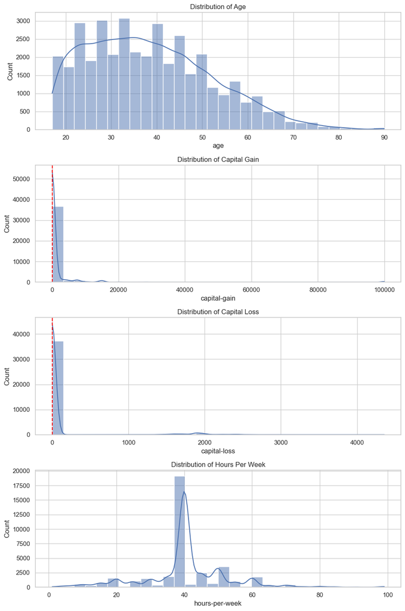

```python
import matplotlib.pyplot as plt
import seaborn as sns

# Setting the aesthetic style
sns.set(style="whitegrid")

# Creating subplots
fig, axs = plt.subplots(4, 1, figsize=(10, 15))

# Plotting the distribution of 'age'
sns.histplot(data=df, x='age', bins=30, kde=True, ax=axs[0])
axs[0].set_title('Distribution of Age')

# Plotting the distribution of 'capital-gain'
sns.histplot(data=df, x='capital-gain', bins=30, kde=True, ax=axs[1])
axs[1].set_title('Distribution of Capital Gain')
# Highlighting zero for capital gain
axs[1].axvline(x=0, color='red', linestyle='--')

# Plotting the distribution of 'capital-loss'
sns.histplot(data=df, x='capital-loss', bins=30, kde=True, ax=axs[2])
axs[2].set_title('Distribution of Capital Loss')
# Highlighting zero for capital loss
axs[2].axvline(x=0, color='red', linestyle='--')

# Plotting the distribution of 'hours-per-week'
sns.histplot(data=df, x='hours-per-week', bins=30, kde=True, ax=axs[3])
axs[3].set_title('Distribution of Hours Per Week')

plt.tight_layout()
plt.show()
```

```python
from sklearn.preprocessing import StandardScaler
import numpy as np

# Initialize the StandardScaler
scaler = StandardScaler()

# Standardize 'age' and 'hours-per-week'
df['age_scaled'] = scaler.fit_transform(df[['age']])
df['hours-per-week_scaled'] = scaler.fit_transform(df[['hours-per-week']])

# Log transform and then standardize 'capital-gain' and 'capital-loss'
df['capital-gain-log'] = np.log1p(df['capital-gain'])
df['capital-loss-log'] = np.log1p(df['capital-loss'])
df['capital-gain-log-scaled'] = scaler.fit_transform(df[['capital-gain-log']])
df['capital-loss-log-scaled'] = scaler.fit_transform(df[['capital-loss-log']])
```

[output not shown]

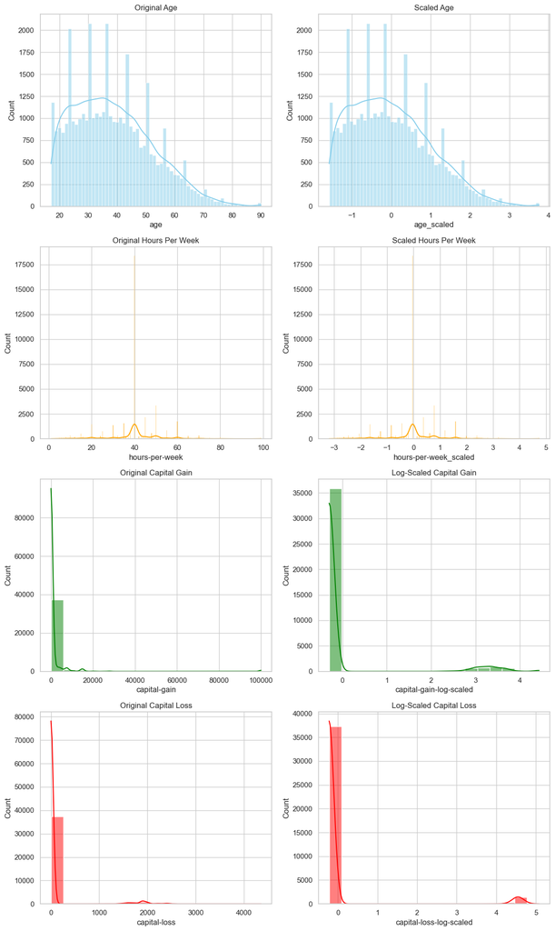

```python
# Plotting
fig, axs = plt.subplots(4, 2, figsize=(12, 20))

# Age
sns.histplot(df['age'], ax=axs[0, 0], kde=True, color="skyblue").set_title('Original Age')
sns.histplot(df['age_scaled'], ax=axs[0, 1], kde=True, color="skyblue").set_title('Scaled Age')

# Hours per week
sns.histplot(df['hours-per-week'], ax=axs[1, 0], kde=True, color="orange").set_title('Original Hours Per Week')
sns.histplot(df['hours-per-week_scaled'], ax=axs[1, 1], kde=True, color="orange").set_title('Scaled Hours Per Week')

# Capital Gain
sns.histplot(df['capital-gain'], ax=axs[2, 0], kde=True, color="green", binrange=(0, df['capital-gain'].max())).set_title('Original Capital Gain')
sns.histplot(df['capital-gain-log-scaled'], ax=axs[2, 1], kde=True, color="green").set_title('Log-Scaled Capital Gain')

# Capital Loss
sns.histplot(df['capital-loss'], ax=axs[3, 0], kde=True, color="red", binrange=(0, df['capital-loss'].max())).set_title('Original Capital Loss')
sns.histplot(df['capital-loss-log-scaled'], ax=axs[3, 1], kde=True, color="red").set_title('Log-Scaled Capital Loss')

plt.tight_layout()
plt.show()
```

**'age' and 'hours-per-week':** These features may benefit from standardization (using StandardScaler), especially if their distributions are close to normal or if we aim to maintain the effects of outliers. Standardization transforms data to have a mean of zero and a standard deviation of one, preserving the shape of the distribution and the relative distances between data points.

**'capital-gain' and 'capital-loss':** Given their skewness and the presence of many zeros, a log transformation followed by standardization might be suitable. The log transformation can help in reducing the skewness, making the distribution more symmetric. After log transformation, applying standardization ensures that these features have a mean of zero and a standard deviation of one, facilitating models' learning process by giving all features the same scale.

2. **Discretization/Binning**
   - **Select a Feature:** Choose a continuous numerical feature (e.g., 'age') that might benefit from being grouped into categories.
   - **Experiment:** Try these common binning methods:
     - **Equal-Width:** Divides the range of the feature into intervals of the same size.
     - **Equal-Frequency:** Makes sure each bin contains roughly the same number of samples.
     - **Custom:** Define bin boundaries based on domain knowledge.
   - **Explain your Strategy:** Why did you choose your binning method? Consider how it might impact potential relationships with the target variable ('class').
   - **Implement:** Use Scikit-learn's binning tools or create custom functions.

# ✍️ Respond to the question in this markdown cell ✍️

```python
# Prepare the age data for binning
age_data = df['age'].values.reshape(-1, 1)
```

```python
# Equal-Width Binning using KBinsDiscretizer (with 'uniform' strategy)
equal_width_bins = KBinsDiscretizer(n_bins=8, encode='ordinal', strategy='uniform')
equal_width_binned_age = equal_width_bins.fit_transform(age_data)
```

```python
# Equal-Frequency Binning using KBinsDiscretizer (with 'quantile' strategy)
equal_freq_bins = KBinsDiscretizer(n_bins=4, encode='ordinal', strategy='quantile')
equal_freq_binned_age = equal_freq_bins.fit_transform(age_data)
```

[output not shown]

Based on domain knowledge, we might define the following age groups:

```python
# Custom Binning
bins = [17, 30, 45, 60, 90]
labels = ['Young Adult', 'Adult', 'Middle-aged', 'Senior']
df['age_custom_bin'] = pd.cut(df['age'], bins=bins, labels=labels, right=False)
```

```python
# Check the distribution for each binning method
equal_width_bin_counts = pd.Series(equal_width_binned_age.flatten()).value_counts().sort_index()
equal_freq_bin_counts = pd.Series(equal_freq_binned_age.flatten()).value_counts().sort_index()
custom_bin_counts = df['age_custom_bin'].value_counts().sort_index()

equal_width_bin_counts, equal_freq_bin_counts, custom_bin_counts
```

```
(0.0    8634
 1.0    9258
 2.0    8706
 3.0    6569
 4.0    3730
 5.0    1588
 6.0     468
 7.0     120
 Name: count, dtype: int64,
 0.0     9627
 1.0     9333
 2.0    10276
 3.0     9837
 Name: count, dtype: int64,
 age_custom_bin
 Young Adult    11661
 Adult          14937
 Middle-aged     9268
 Senior          3167
 Name: count, dtype: int64)
```

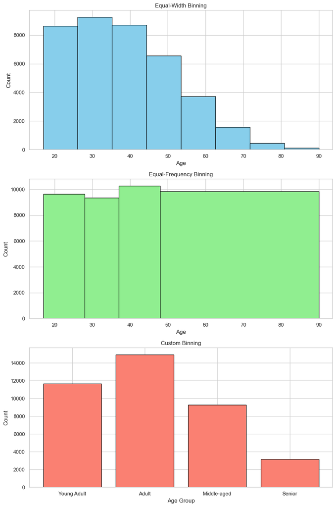

```python
import matplotlib.pyplot as plt

# Prepare data for plotting
equal_width_bin_edges = equal_width_bins.bin_edges_[0]
equal_freq_bin_edges = np.quantile(df['age'], [0, 0.25, 0.5, 0.75, 1])

# Plotting
fig, axes = plt.subplots(3, 1, figsize=(10, 15))

# Equal-Width Bins
axes[0].hist(df['age'], bins=equal_width_bin_edges, color='skyblue', edgecolor='black')
axes[0].set_title('Equal-Width Binning')
axes[0].set_xlabel('Age')
axes[0].set_ylabel('Count')

# Equal-Frequency Bins
axes[1].hist(df['age'], bins=equal_freq_bin_edges, color='lightgreen', edgecolor='black')
axes[1].set_title('Equal-Frequency Binning')
axes[1].set_xlabel('Age')
axes[1].set_ylabel('Count')

# Custom Bins
custom_bin_midpoints = [(a + b) / 2 for a, b in zip(bins[:-1], bins[1:])]
axes[2].bar(labels, custom_bin_counts, color='salmon', edgecolor='black')
axes[2].set_title('Custom Binning')
axes[2].set_xlabel('Age Group')
axes[2].set_ylabel('Count')

plt.tight_layout()
plt.show()
```

Custom binning categorizes individuals into groups that represent significant stages in a person's life, such as 'Young Adult', 'Adult', 'Middle-aged', and 'Senior'. These stages are often associated with distinct economic behaviors, career stages, and income levels. For example, 'Young Adults' might be entering the workforce or in early career stages, typically earning less. In contrast, 'Adults' and 'Middle-aged' individuals might be at the peak of their careers, potentially earning more. 'Seniors' might be retired, affecting their income classification. By grouping ages into meaningful categories, custom binning can make models more interpretable. We can more easily understand and explain how age affects income levels when the age feature is represented by clear, life-stage-based categories rather than a continuous variable or less intuitive bins.

```python
# Re-apply custom binning to 'age' using the previously defined bins and labels
df['age_custom_bin'] = pd.cut(df['age'], bins=bins, labels=labels, right=False)
df.drop('age', axis=1, inplace=True)  # Remove the original 'age' column to avoid duplication
```

```python
# Encode the custom binned 'age' column
df['age_custom_bin'] = df['age_custom_bin'].cat.codes
```

```python
df
```

|  | fnlwgt | capital-gain | capital-loss | hours-per-week | class | workclass_Federal-gov | workclass_Local-gov | workclass_Never-worked | workclass_Private | workclass_Self-emp-inc | ... | native-country_Unknown | native-country_Vietnam | native-country_Yugoslavia | age_scaled | hours-per-week_scaled | capital-gain-log | capital-loss-log | capital-gain-log-scaled | capital-loss-log-scaled | age_custom_bin |
| --- | --- | --- | --- | --- | --- | --- | --- | --- | --- | --- | --- | --- | --- | --- | --- | --- | --- | --- | --- | --- | --- |
| 0 | 300379.0 | 0.0 | 0.0 | 12 | <=50K | 0.0 | 0.0 | 0.0 | 1.0 | 0.0 | ... | 0.0 | 0.0 | 0.0 | -1.506076 | -2.296923 | 0.000000 | 0.0 | -0.296591 | -0.220149 | 0 |
| 1 | 34292.0 | 0.0 | 0.0 | 38 | <=50K | 0.0 | 0.0 | 0.0 | 1.0 | 0.0 | ... | 0.0 | 0.0 | 0.0 | -0.701827 | -0.193298 | 0.000000 | 0.0 | -0.296591 | -0.220149 | 0 |
| 2 | 102345.0 | 0.0 | 0.0 | 52 | <=50K | 0.0 | 0.0 | 0.0 | 1.0 | 0.0 | ... | 0.0 | 0.0 | 0.0 | -0.701827 | 0.939423 | 0.000000 | 0.0 | -0.296591 | -0.220149 | 0 |
| 3 | 83444.0 | 0.0 | 0.0 | 85 | >50K | 0.0 | 0.0 | 0.0 | 0.0 | 1.0 | ... | 0.0 | 0.0 | 0.0 | 0.760444 | 3.609408 | 0.000000 | 0.0 | -0.296591 | -0.220149 | 2 |
| 4 | 40077.0 | 0.0 | 0.0 | 50 | >50K | 0.0 | 0.0 | 0.0 | 1.0 | 0.0 | ... | 0.0 | 0.0 | 0.0 | -0.043805 | 0.777606 | 0.000000 | 0.0 | -0.296591 | -0.220149 | 1 |
| ... | ... | ... | ... | ... | ... | ... | ... | ... | ... | ... | ... | ... | ... | ... | ... | ... | ... | ... | ... | ... | ... |
| 39068 | 37997.0 | 0.0 | 0.0 | 40 | <=50K | 1.0 | 0.0 | 0.0 | 0.0 | 0.0 | ... | 0.0 | 0.0 | 0.0 | 0.248649 | -0.031481 | 0.000000 | 0.0 | -0.296591 | -0.220149 | 1 |
| 39069 | 326936.0 | 0.0 | 0.0 | 40 | <=50K | 0.0 | 0.0 | 0.0 | 0.0 | 0.0 | ... | 0.0 | 0.0 | 0.0 | 1.930261 | -0.031481 | 0.000000 | 0.0 | -0.296591 | -0.220149 | 3 |
| 39070 | 229466.0 | 0.0 | 0.0 | 50 | >50K | 0.0 | 0.0 | 0.0 | 0.0 | 1.0 | ... | 0.0 | 0.0 | 0.0 | 0.394877 | 0.777606 | 0.000000 | 0.0 | -0.296591 | -0.220149 | 1 |
| 39071 | 265954.0 | 0.0 | 0.0 | 40 | <=50K | 0.0 | 0.0 | 0.0 | 1.0 | 0.0 | ... | 0.0 | 0.0 | 0.0 | -0.263146 | -0.031481 | 0.000000 | 0.0 | -0.296591 | -0.220149 | 1 |
| 39072 | 77660.0 | 15024.0 | 0.0 | 50 | >50K | 0.0 | 0.0 | 0.0 | 0.0 | 1.0 | ... | 0.0 | 0.0 | 0.0 | 0.614217 | 0.777606 | 9.617471 | 0.0 | 3.653938 | -0.220149 | 2 |

39073 rows × 98 columns

## Question 2: Regularized Logistic Regression (45 points)

### **Part A: Logistic Regression Baseline (15 points)**

1. **Import:** Start with importing the Logistic Regression classifier:

```python
from sklearn.linear_model import LogisticRegression
from sklearn.model_selection import train_test_split
from sklearn.metrics import accuracy_score, classification_report
```

```python
df.drop('capital-gain', axis=1, inplace=True)
df.drop('capital-loss', axis=1, inplace=True)
df.drop('age_scaled', axis=1, inplace=True)
df.drop('capital-gain-log', axis=1, inplace=True)
df.drop('capital-loss-log', axis=1, inplace=True)
df.drop('hours-per-week', axis=1, inplace=True)
```

```python
df.columns
```

```
Index(['fnlwgt', 'class', 'workclass_Federal-gov', 'workclass_Local-gov',
       'workclass_Never-worked', 'workclass_Private', 'workclass_Self-emp-inc',
       'workclass_Self-emp-not-inc', 'workclass_State-gov',
       'workclass_Unknown', 'workclass_Without-pay', 'education_encoded',
       'marital-status_Divorced', 'marital-status_Married-AF-spouse',
       'marital-status_Married-civ-spouse',
       'marital-status_Married-spouse-absent', 'marital-status_Never-married',
       'marital-status_Separated', 'marital-status_Widowed',
       'occupation_Adm-clerical', 'occupation_Armed-Forces',
       'occupation_Craft-repair', 'occupation_Exec-managerial',
       'occupation_Farming-fishing', 'occupation_Handlers-cleaners',
       'occupation_Machine-op-inspct', 'occupation_Other-service',
       'occupation_Priv-house-serv', 'occupation_Prof-specialty',
       'occupation_Protective-serv', 'occupation_Sales',
       'occupation_Tech-support', 'occupation_Transport-moving',
       'occupation_Unknown', 'relationship_Husband',
       'relationship_Not-in-family', 'relationship_Other-relative',
       'relationship_Own-child', 'relationship_Unmarried', 'relationship_Wife',
       'race_Amer-Indian-Eskimo', 'race_Asian-Pac-Islander', 'race_Black',
       'race_Other', 'race_White', 'sex_encoded', 'native-country_Cambodia',
       'native-country_Canada', 'native-country_China',
       'native-country_Columbia', 'native-country_Cuba',
       'native-country_Dominican-Republic', 'native-country_Ecuador',
       'native-country_El-Salvador', 'native-country_England',
       'native-country_France', 'native-country_Germany',
       'native-country_Greece', 'native-country_Guatemala',
       'native-country_Haiti', 'native-country_Holand-Netherlands',
       'native-country_Honduras', 'native-country_Hong',
       'native-country_Hungary', 'native-country_India', 'native-country_Iran',
       'native-country_Ireland', 'native-country_Italy',
       'native-country_Jamaica', 'native-country_Japan', 'native-country_Laos',
       'native-country_Mexico', 'native-country_Nicaragua',
       'native-country_Outlying-US(Guam-USVI-etc)', 'native-country_Peru',
       'native-country_Philippines', 'native-country_Poland',
       'native-country_Portugal', 'native-country_Puerto-Rico',
       'native-country_Scotland', 'native-country_South',
       'native-country_Taiwan', 'native-country_Thailand',
       'native-country_Trinadad&Tobago', 'native-country_United-States',
       'native-country_Unknown', 'native-country_Vietnam',
       'native-country_Yugoslavia', 'hours-per-week_scaled',
       'capital-gain-log-scaled', 'capital-loss-log-scaled', 'age_custom_bin'],
      dtype='object')
```

2. **Split Data (X, y):** Prepare your features (X), including the newly engineered ones, and the binary target variable ('class').

```python
# Split the data into features and target variable
X = df.drop('class', axis=1)
y = df['class']
```

3. **Train/Test Split:** Use `train_test_split`.

```python
X_train, X_test, y_train, y_test = train_test_split(X, y, test_size=0.3, random_state=42)
```

4. **Model Training:**
   - Instantiate a `LogisticRegression` object (with default parameters for now).
   - Fit the model on your training data.

```python
log_reg = LogisticRegression(max_iter=1000)
log_reg.fit(X_train, y_train)  # Using unscaled data for simplicity in this example
```

```
LogisticRegression(max_iter=1000)
```

5. **Predictions:** Make predictions on the test set.

```python
y_pred = log_reg.predict(X_test)
```

6. **Evaluation:**
   - Calculate accuracy.
   - Interpret your findings. How well does the model perform without regularization?

```python
accuracy = accuracy_score(y_test, y_pred)
classification_rep = classification_report(y_test, y_pred)

accuracy
```

```
0.8438832963658078
```

# ✍️ Respond to the question in this markdown cell ✍️

An accuracy of approximately 84.39% indicates that the logistic regression model correctly predicts the income class (<=50K or >50K) for about 84 out of every 100 individuals in the test set. This is a solid starting point, especially considering this performance was achieved without explicitly addressing regularization in the model configuration.

### **Part B: Regularization for Better Generalization (15 points)**

1. **L1 and L2:**
   - Briefly describe L1 (Lasso) and L2 (Ridge) regularization. Highlight their ability to prevent overfitting and potentially improve generalization.

# ✍️ Respond to the question in this markdown cell ✍️

**L1 Regularization (Lasso)**

- **Mechanism:** Adds the absolute value of the coefficients to the loss function. This is represented as λ|β|, where λ is the regularization strength and β are the coefficients.
- **Effect on Model:** Can reduce the coefficients of less important features to zero, effectively performing feature selection. This leads to sparse models where only a subset of all the provided features contribute to the prediction.
- **Use Case:** Useful when we believe many features are irrelevant or when we prefer a model with fewer features.

**L2 Regularization (Ridge)**

- **Mechanism:** Adds the square of the coefficients to the loss function. This is represented as λβ².
- **Effect on Model:** Shrinks the coefficients evenly but does not necessarily reduce them to zero. This means all features are kept, but their influence on the predictive model is moderated.
- **Use Case:** Beneficial when we have multicollinearity among features or when we aim to penalize the influence of features without completely removing them.

**Preventing Overfitting and Improving Generalization**

- **Overfitting Prevention:** Both L1 and L2 regularization help in preventing overfitting by penalizing large coefficients, which can be a sign of the model being too tailored to the training data. This penalization encourages simpler models that are less likely to capture the noise in the training data.
- **Generalization Improvement:** By preventing overfitting, regularization techniques help the model generalize better to unseen data. A model that is less complex and more generalized is likely to perform better on test data or in real-world applications.
2. **Implement Regularization:**
   - Create a `LogisticRegression` object with `penalty='l1'`.
   - Train it using different regularization strengths by varying the hyperparameter:
     - `C`: Inverse of regularization strength (smaller values mean stronger regularization)

```python
C_values = [0.001, 0.01, 0.1, 1, 10, 100]
models = []
for C in C_values:
    model = LogisticRegression(penalty='l1', C=C, solver='liblinear')
    model.fit(X_train, y_train)
    models.append(model)
```

3. **Comparison:**
   - Evaluate model performance (test set metrics) across the two different regularization settings.
   - Create a table to see the impact on coefficients (weights).

```python
accuracies = []
for model in models:
    y_pred = model.predict(X_test)
    accuracy = accuracy_score(y_test, y_pred)
    accuracies.append(accuracy)
```

```python
coefficients = []
for model in models:
    coefficients.append(model.coef_)
```

```python
comparison_table = pd.DataFrame({
    'C Value': C_values,
    'Accuracy': accuracies,
    'Coefficients': coefficients
})

print(comparison_table)
```

```
   C Value  Accuracy                                       Coefficients
0    0.001  0.787494  [[-3.9404911663247975e-06, 0.0, 0.0, 0.0, 0.0,...
1    0.010  0.839106  [[2.1157586866821586e-08, 0.0, 0.0, 0.0, 0.0, ...
2    0.100  0.846699  [[5.796046682871198e-07, 0.42449807718945404, ...
3    1.000  0.845845  [[6.94297449655363e-07, -0.0538919269763358, -...
4   10.000  0.845078  [[7.144697182434035e-07, -0.39708505010942624,...
5  100.000  0.844992  [[7.425341985361171e-07, -0.09040362468047937,...
```

### **Part C: Finding the Best Regularization Strength (15 points)**

**Goal:** Find the optimal 'C' value (regularization strength) for both L1 and L2 regularization that maximizes performance while preventing overfitting.

1. **Parameter Grid:** Define ranges of 'C' values to test. Below is a starting point, **adjust it based on your previous results**:

```python
C_values = [0.001, 0.01, 0.1, 1, 10, 100]
```

```python
# For L1 Regularization
log_reg_l1_cv = LogisticRegressionCV(Cs=C_values, cv=5, penalty='l1', solver='liblinear', random_state=42, max_iter=1000)
log_reg_l1_cv.fit(X_train, y_train)

# Evaluate the model with the best 'C' value
y_pred_l1 = log_reg_l1_cv.predict(X_test)
accuracy_l1 = accuracy_score(y_test, y_pred_l1)
optimal_c_l1 = log_reg_l1_cv.C_[0]

# For L2 Regularization
log_reg_l2_cv = LogisticRegressionCV(Cs=C_values, cv=5, penalty='l2', solver='liblinear', random_state=42, max_iter=1000)
log_reg_l2_cv.fit(X_train, y_train)

# Evaluate the model with the best 'C' value
y_pred_l2 = log_reg_l2_cv.predict(X_test)
accuracy_l2 = accuracy_score(y_test, y_pred_l2)
optimal_c_l2 = log_reg_l2_cv.C_[0]
```

```python
# Results
print("L1 Regularization: Optimal C =", optimal_c_l1, "with accuracy:", accuracy_l1)
print("L2 Regularization: Optimal C =", optimal_c_l2, "with accuracy:", accuracy_l2)
```

```
L1 Regularization: Optimal C = 1.0 with accuracy: 0.8455894898481487
L2 Regularization: Optimal C = 0.001 with accuracy: 0.7625831769322641
```

2. **Manual Exploration:**
- Create a loop to iterate through the 'C' values.
- For each 'C' value:
  - Train an L1 regularized model (`penalty='l1'`).
  - Train an L2 regularized model (`penalty='l2'`).
  - Evaluate both models on the test set (e.g., using accuracy).
  - Store the results.

```python
# Initialize lists to store results
results = {"C": [], "L1 Accuracy": [], "L2 Accuracy": []}

for C in C_values:
    # Train L1 regularized model
    model_l1 = LogisticRegression(penalty='l1', C=C, solver='liblinear', max_iter=1000)
    model_l1.fit(X_train, y_train)
    y_pred_l1 = model_l1.predict(X_test)
    accuracy_l1 = accuracy_score(y_test, y_pred_l1)

    # Train L2 regularized model
    model_l2 = LogisticRegression(penalty='l2', C=C, solver='liblinear', max_iter=1000)
    model_l2.fit(X_train, y_train)
    y_pred_l2 = model_l2.predict(X_test)
    accuracy_l2 = accuracy_score(y_test, y_pred_l2)

    # Store the results
    results["C"].append(C)
    results["L1 Accuracy"].append(accuracy_l1)
    results["L2 Accuracy"].append(accuracy_l2)

# Convert results to a DataFrame for easier visualization
import pandas as pd
results_df = pd.DataFrame(results)
results_df
```

|  | C | L1 Accuracy | L2 Accuracy |
| --- | --- | --- | --- |
| 0 | 0.001 | 0.788005 | 0.762583 |
| 1 | 0.010 | 0.839021 | 0.762583 |
| 2 | 0.100 | 0.846784 | 0.762583 |
| 3 | 1.000 | 0.845845 | 0.762583 |
| 4 | 10.000 | 0.845163 | 0.762583 |
| 5 | 100.000 | 0.844907 | 0.762583 |

3. **Optimal Settings:**
- Identify the 'C' value that led to the best test set performance for each regularization type (L1 and L2).
- Report these optimal 'C' values.

```python
# For L1 Regularization
optimal_l1 = results_df.loc[results_df['L1 Accuracy'].idxmax()]
optimal_c_l1 = optimal_l1['C']
max_accuracy_l1 = optimal_l1['L1 Accuracy']

# For L2 Regularization
optimal_l2 = results_df.loc[results_df['L2 Accuracy'].idxmax()]
optimal_c_l2 = optimal_l2['C']
max_accuracy_l2 = optimal_l2['L2 Accuracy']

# Report the optimal 'C' values and the corresponding accuracies
print(f"L1 Regularization: Optimal C = {optimal_c_l1} with accuracy = {max_accuracy_l1}")
print(f"L2 Regularization: Optimal C = {optimal_c_l2} with accuracy = {max_accuracy_l2}")
```

```
L1 Regularization: Optimal C = 0.1 with accuracy = 0.8467838252857874
L2 Regularization: Optimal C = 0.001 with accuracy = 0.7625831769322641
```

# ✍️ Respond to the question in this markdown cell ✍️

## Question 3: Reflection & Best Practices (20 points)

### **Part A: Encoding Insights (5 points)**

- Discuss the reasons behind your encoding choices for categorical features. Explain your decision-making process.
- If you explored multiple encoding methods, compare their impact on model performance. What did you learn about different encoders in this context?

# ✍️ Respond to the question in this markdown cell ✍️

**Ordinal Features:** For features displaying a clear hierarchy, such as education level, ordinal encoding was applied. This method preserves the natural order within the data, making it suitable for capturing the gradations in education levels, which are expected to correlate with outcomes like income or job status.

**Binary and Simple Nominal Features:** Features with a limited number of categories, where a natural binary distinction exists or where categories are easily distinguishable without implying order, such as sex, were encoded using label encoding. This approach maintains simplicity and computational efficiency, allowing for straightforward interpretation of an individual's attributes in the context of the model's predictions.

**Complex Nominal Features:** Most other features, characterized by nominal data without inherent order, were subjected to one-hot encoding. This strategy prevents the model from incorrectly assuming any ordinal relationship among categories. However, it was observed that this approach could significantly increase the dimensionality of the dataset for features with many unique categories, complicating the analysis and potentially impacting model performance due to the curse of dimensionality.

### **Part B: Regularization Impact (10 points)**

- Describe the observed effects of L1 and L2 regularization on your model. Did it help address potential overfitting?
- How did regularization influence feature weights (coefficients)? Provide specific examples if possible.
- Connect your findings on optimal 'C' values with the goals of regularization.

# ✍️ Respond to the question in this markdown cell ✍️

**Without Regularization:** The baseline model achieved an accuracy of approximately 84.39%. This serves as a reference point for assessing the impact of regularization.

**L1 Regularization:** With an optimal 'C' of 0.1, the model reached an accuracy of 84.68%. The slight improvement in accuracy suggests that L1 regularization effectively contributed to enhancing the model's generalization capabilities. L1's capacity to induce sparsity in the coefficients likely eliminated some irrelevant features from the model, reducing the risk of overfitting.

In theory, L1 tends to push the coefficients of less important features towards zero, effectively performing feature selection. For instance, if a feature related to a specific occupation had a minimal impact on the income prediction, its coefficient might be reduced to zero, omitting it from the model.

L2, on the other hand, shrinks the coefficients towards zero but rarely to zero. This means all features remain in the model but with reduced influence. This can be beneficial when all features contain some relevant information but might also dilute the impact of truly important features.

### **Part C: Lessons Learned (5 points)**

- Reflect on the key concepts about feature engineering and regularization that this assignment reinforced for you.
- Are there any new insights you gained, or misconceptions that this exercise helped clarify?

# ✍️ Respond to the question in this markdown cell ✍️

**New Insights**

The challenge of balancing the introduction of useful information through one-hot encoding against the risk of increasing dimensionality highlighted the delicate trade-off in feature engineering. It emphasized the need for strategies like feature selection or regularization to manage high-dimensional data effectively.

Observing the impact of different regularization strengths on model performance provided a clear demonstration of how overfitting and underfitting manifest. Specifically, how too much regularization can harm the model's ability to learn (underfitting), while too little can lead to overfitting.

This assignment provided practical insights into how L1 regularization promotes sparsity by pushing certain coefficients to zero, effectively performing feature selection, whereas L2 regularization shrinks coefficients more uniformly without inducing sparsity. This distinction is crucial for understanding which regularization technique to apply based on the specific goals, such as dimensionality reduction or model simplification.